← HomeJASP Student Developers Group

SESSION 01

Learn · Build · Explore

# Your First JASP Module

From zero to your own button in JASP

Leo Liu · Thu 12 Nov (REC L0.10) / Tue 17 Nov (REC GS.34) · Bring your laptop

# Session 1: Your First JASP Module

## Before we begin ⏱ 5 min 0:00–0:05

A quick check before we start. **Don’t worry if something isn’t ready yet:** we’ll sort it out together in the first minutes.

- 💻 Laptop
- 📶 Connected to the Wi-Fi
- 🧮 JASP (nightly build) installed · [download ↗](https://static.jasp-stats.org/Nightlies/)
- 📊 R (**4.5 or newer**) and RStudio installed · [how to ↗](https://rstudio-education.github.io/hopr/starting.html) · check your version: run `R.version.string` in RStudio
- 🛠️ Build tools, so R can compile packages
  - **Mac:** open Terminal and run `xcode-select --install` (if it says *already installed*: you’re done 🎉)
  - **Windows:** install [Rtools45 ↗](https://cran.r-project.org/bin/windows/Rtools/) (a big download, so best done before the session)
- 🐙 A GitHub account (know your username and password) · [sign up ↗](https://github.com/signup)
- 💬 Joined our Mattermost channel · no account yet? Ask Leo for an invite

**Something missing?** Raise your hand. The first part of today involves some waiting while things install, so there's time to catch up.

## Overview ⏱ 15 min 0:05–0:20

The big picture: **what** we’re building this term, **how** we’ll get there, **what’s in it** for you, **when** we meet, and what we’ll do **today**.

### 🕵️ The mission

THIS TERM · SECRET MISSION

### Can you make JASP do something new?

No coding experience required. Just bring your curiosity.

**🎁 Reveal the missionClick to unlock ↗**

WELCOME TO THE TEAM

### You're not just using JASP. You're building it.

Welcome to the **JASP Student Developers Group**! This term, we'll build a **data-wrangling module** together: step by step, session by session, until it's a tool real researchers can use.

#### Meet our mystery dataset 🕵️

It looks normal at first glance. What could be hiding in it?

|  | ID | wave | Age | gender | Condition | anxiety_1 | Anx3 | anx_4R | ANXIETY 5 | anx.6 | … |
| --- | --- | --- | --- | --- | --- | --- | --- | --- | --- | --- | --- |
| 1 | P001 | pre | 20 | female | control | 2 | 4 | 4 | 4 | 3 | … |
| 2 | P001 | follow-up | 20 | F | Control | 2 | 2 | 3 | 4 | 3 | … |
| 3 | P001 | post | 20 | F | control | 3 | 3 | 4 | 3 |  | … |
| 4 | P002 | pre | 31 | Male | Treatment | 3 | 3 | 3 | 4 | 3 | … |
| 5 | P002 | post | 31 | Male | Treatment | 2 | 2 | 4 | 3 |  | … |

First 5 of 351 rows · 15 columns

⬇️ Download the dataset (.csv)📖 Codebook

Every tool we build will help us investigate the data. How many problems will we discover?

### 🤔 But, how?

👆 Click a card to see what we'll build in each part

→

### 🎒 Loot & side quests

What do you get out of this? Click a badge to unlock it.

**0** / 6 unlocked

⚔️ OPTIONAL SIDE QUESTS

Not every contribution is code! Side quests are open to everyone, any time, including **less coding-related work**: writing a blog post about a new JASP module, or helping build an example library from real exam questions. Prefer coding? Fix a beginner-friendly issue on GitHub. Contact me anytime!

### 📅 How we meet

😰 “I can’t code yet. How am I supposed to build a JASP module?”

That’s exactly what our meetings are for: **we show you, then you try**, one small step at a time.

💡 THURSDAYS · 11:30–13:00**Sessions***We show you how.*

💬 Explain60 min

🧩 Practice30 min

🧩 ALTERNATE THURSDAYS · 15:00–16:30**Practicals***You try it, with backup.*

🔁 Recap30 min

❓ Q&A30 min

🧩 Practice30 min

**🤔 What if I get stuck?**

Ask! Every practical has Q&A time, and our Mattermost channel is open all week.

**📅 I can’t come every week**

No problem. Pick your plan in the calendar on our homepage.

**📝 Is this graded?**

No grades. No tests. No stupid questions.

📅 See the full calendar on our homepage →

### 🎯 Today’s route

🎯 **Today's win:** your own module runs in JASP, and you change its menu.

👋 Meet**→**⚙️ Set up**→**🚀 Load**→**🧩 Explore**→**📋 Your menu

👆 Click a step to jump there

### 👋 Your turn: introductions

Before we touch any code: who’s here?

🙋 Your name🎓 Your programme💛 Your favorite thing

## Get the module & a GitHub token ⏱ 5 min 0:20–0:25

🌐 Browser Grab the module

Download the starter module and unzip it somewhere you’ll find again (e.g. your Documents folder).

⬇️ Download jaspDataWrangling.zip

🐙 GitHub Create a token

Logged in to GitHub? Open https://github.com/settings/tokens/new and fill in:

Note`JASP`

Expiration`90 days`

Scopes**☐ tick nothing!**

Then**Generate token ↓**

**🤔 Why a token at all?**

Our module downloads two packages (`jaspBase`, `jaspGraphs`) from GitHub. Without a login, GitHub allows only **60 requests per hour per network**, and the whole room shares one network. A token gives each of you your own allowance. With no boxes ticked, it can only read public stuff, so it can't do any harm.

**Copy it now!**

GitHub shows the token (`ghp_...`) **only once**. Lost it? No drama: just make a new one.

📊 RStudio Hand the token to R

Open RStudio (**just RStudio, not the project yet**) and run in the Console:

```r
file.edit("~/.Renviron")
```

Add this line with your own token, **press Enter once** (R can skip a last line without a line break 🙃), and save:

```
GITHUB_PAT=ghp_paste-your-token-here
```

**🤔 Why this file?**

`.Renviron` is read every time R starts, so you only do this once on this computer. R picks it up in the **next** R session, which starts automatically when you open the project.

- Module downloaded & unzipped
- Logged in to GitHub
- Token generated and copied
- `GITHUB_PAT=...` saved in `.Renviron`

## Install the module ⏱ 20 min 0:25–0:45

📁 Finder / Explorer Open the project

Double-click `jaspDataWrangling.Rproj`. RStudio’s Console should greet you with:

```
- Project '~/.../jaspDataWrangling' loaded. [renv 1.x.x]
```

**😵 No such line?**

RStudio didn't open it as a project. Use **File → Open Project…** and pick the `.Rproj` file.

📊 RStudio Did the token arrive?

```r
Sys.getenv("GITHUB_PAT")
```

It should print something starting with `ghp_`.

**😵 It prints an empty ""**

R hasn't read your `.Renviron` yet. **Session → Restart R**, then try again.

📊 RStudio Install everything

```r
renv::install(".")
```

Sit back ☕ This compiles a few packages and takes a while. You’re done when R says `Successfully installed`.

**😵 Red ERROR somewhere?**

Scroll **up** to the *first* red ERROR: that's the real cause. `dependency 'X' is not available` only means X failed earlier. Screenshot that first error and wave at Leo 👋

- Project opened (saw the `Project ... loaded` line)
- Installation finished (`Successfully installed ...`)

## Load the module in JASP ⏱ 10 min 0:45–0:55

🧮 JASP Open the developer settings

Menu (☰, top left) → **Preferences** → **Advanced**. Find the **Development module** box and keep this window open.

📊 RStudio Find where renv put everything

With the project still open, run:

```r
.libPaths()
```

Copy the **first** path, the one marked `[1]`. It contains `jaspDataWrangling` and ends with your R version and computer type, something like:

```
[1] "/Users/you/.../jaspDataWrangling-5f03db05/macos/R-4.5/aarch64-apple-darwin20"
```

Copy only the path itself: no `[1]`, no quotes.

🧮 JASP Paste it

Under **Development module**: tick **Enable renv mode**, paste the path into **Project library**, and type `jaspDataWrangling` as **Module name**.

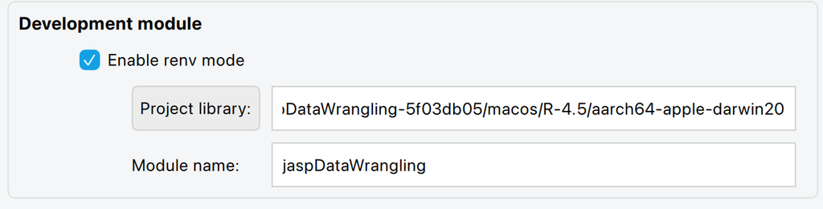

🧮 JASP Lift-off!

Click **Install Developer Module**. A **Data Wrangling** button appears on the ribbon 🎉 Open **Control Playground** and poke every control: watch the text, table and plot react. Then peek at **Missing Values**: that’s the one you’ll build.

- Enable renv mode ticked
- Library path pasted
- Module visible in the JASP menu 🎉

## How a JASP module works ⏱ 15 min 0:55–1:10

You just played with **Control Playground**. Time to open the hood! A JASP module is an **R package** with a few extra files for the JASP interface. Every analysis is made of three pieces:

📋

**Description.qml**Menu entryPuts “Control Playground” in the ribbon

→

🎛️

**controlPlayground.qml**ControlsThe left panel you clicked

→

📊

**controlPlayground.R**ComputationThe text, table & plot on the right

📂 What’s in the box? Click any file or folder

👈 Pick a file to find out what it does.  
today later don’t touch

### 📋 Start with the menu

The easiest piece to see: `inst/Description.qml` decides what appears when you click **Data Wrangling** on the ribbon. Open it and compare it with the menu in JASP:

```
GroupTitle
{
    title: qsTr("Playground")              // a heading in the menu
}

Analysis
{
    title: qsTr("Control Playground")      // an item you can click
    func : "controlPlayground"             // the R function it runs
    qml  : "controlPlayground.qml"         // the window it opens
}
```

**Your first edit:** add a heading of your own to the **Data Wrangling** menu. Any title you like! No code given this time: the snippet above has everything you need.

When you’re done: save → in RStudio’s Console run `renv::install(".")` → in JASP, **Install Developer Module** again → click **Data Wrangling**.

**💡 Hint 1**

How did the heading *“Playground”* get into the menu? Find that word in `Description.qml`.

**💡 Hint 2**

You need a new block of the same type as the one around *“Playground”*. Copy it, change one thing. Where you paste it decides where it appears.

**🔓 Still stuck? Show the answer**

```
GroupTitle
{
    title: qsTr("My corner")
}
```

Paste it just above the last `}` of the file, so it lands at the bottom of the menu.

- My heading shows up in the menu
- Bonus: move it *between* Control Playground and Missing Values. What changes?

➡️**To be continued in Session 2**Bug hunt, your first button, and your first R codeOpen →

## Wrap-up ⏱ 5 min 1:10–1:15

### 🏆 Achievements unlocked

Your badges light up by themselves as you tick off the missions on this page. How many did you collect?

**0** / 3

🎒🔒**Well Prepared**Laptop, tools and accounts: all set.

⚙️🔒**Setup Survivor**Your own JASP module runs on your laptop.

📋🔒**Menu Maker**You changed what JASP shows in its menu.

### 📅 What’s next

Thu 19 Nov · 15:00–16:30 · 📍 REC GS.34**🧩 Practical 1: R Puzzles**

20 puzzles with the mystery dataset, from zero R to writing your own functions. Pick your level! Also the place to fix any leftover setup problems.

Thu 26 Nov · 11:30–13:00 · 📍 REC JKK.26**💡 Session 2: From Button to Output →**

We pick up where we stopped: a bug hunt, your first button, and your first R code.

🆘 Something broke at home? Post it on Mattermost, or bring your laptop to the practical.👀 Curious? Peek at the other files in `inst/qml/`. What else could you change?

**🕵️ A first peek**

Next week, in R Puzzles, you’ll compute a simple average from the mystery dataset… and something will look *very* wrong.

### 🧭 Curious what else you could work on?

Have a look at our list of potential student projects: ideas from the JASP team, ideas from other students, and beginner-friendly issues on GitHub. Some involve a lot of coding, some hardly any.

[📋 Potential student projects ↗](https://docs.google.com/spreadsheets/d/1SUtcm54EjAVyw6KdJ-t5AjNIC07EKB0Yocrb1vaSB7M/edit?usp=sharing)

👋**Thank you for building with us today!**

Until next time, and happy coding.

*Leo & the JASP Student Developers*